# Actividad

# Entregar

Archivo PDF de la actividad y la liga de la actividad en su repostitorio.

# Nota:

Esta actividad se evaluará de acuerdo a la rúbrica en Canvas.

Al integrante que no participe en la actividad no se le tomará en cuenta para la calificación.

El límite para entregar las actividades es el viernes antes de las 23:59.

# Importante:

- Colocar nombre en ejes en gráficas
- Nombre en gráficas
- Conclusiones con el nombre de cada alumno
- Contestar cada pregunta

# **Presion Arterial**

1. Carga los datos del archivo **presion.csv**

```python
import pandas as pd
import numpy as np
import matplotlib.pyplot as plt
import seaborn as sns
from sklearn.linear_model import LinearRegression
from sklearn.model_selection import train_test_split
from sklearn.metrics import mean_squared_error
from sklearn.metrics import r2_score
from sklearn.metrics import mean_absolute_error
from sklearn.metrics import mean_squared_log_error
from sklearn.metrics import median_absolute_error
```

```python
df = pd.read_csv('data/presion.csv')
df.head()
```

|  | edad | Average of ap_hi | Average of ap_lo |
| --- | --- | --- | --- |
| 0 | 30 | 112.500000 | 72.500000 |
| 1 | 39 | 119.029340 | 88.229829 |
| 2 | 40 | 119.789630 | 85.858889 |
| 3 | 41 | 121.490862 | 90.344648 |
| 4 | 42 | 120.163872 | 89.887957 |

1. Gráfica la información en el eje de las x la edad y en el eje y la presión ( alta y baja)

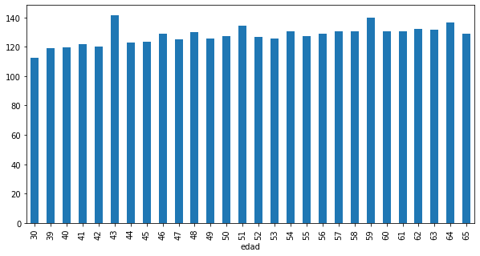

```python
# group by age
df_age = df.groupby('edad').mean()

# age vs Average of ap_hi
age_vs_ap_hi = df_age['Average of ap_hi']
age_vs_ap_hi.plot(kind='bar', figsize=(10, 5))
```

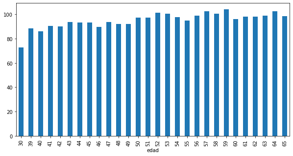

```python
# age vs Average of ap_lo
age_vs_ap_lo = df_age['Average of ap_lo']
age_vs_ap_lo.plot(kind='bar', figsize=(10, 5))
```

1. Genera una regresión líneal para obtener una aproximación de la ecuación $$ y = ax + b $$ donde $ a $ se conoce comúnmente como **pendiente**, y $ b $ se conoce comúnmente como **intersección**.

```python
# Linear Regression between age and ap_hi
X = df_age.index.values.reshape(-1, 1)
y = df_age['Average of ap_hi'].values.reshape(-1, 1)
X_train, X_test, y_train, y_test = train_test_split(X, y, test_size=0.2, random_state=0)
regressor_hi = LinearRegression()
regressor_hi.fit(X_train, y_train)
y_pred = regressor_hi.predict(X_test)
df_age['ap_hi_pred'] = regressor_hi.predict(X)
```

```python
# Linear Regression between age and ap_lo
X = df_age.index.values.reshape(-1, 1)
y = df_age['Average of ap_lo'].values.reshape(-1, 1)
X_train, X_test, y_train, y_test = train_test_split(X, y, test_size=0.2, random_state=0)
regressor_lo = LinearRegression()
regressor_lo.fit(X_train, y_train)
y_pred = regressor_lo.predict(X_test)
df_age['ap_lo_pred'] = regressor_lo.predict(X)
```

1. Gráfica los datos reales vs modelo obtenido.

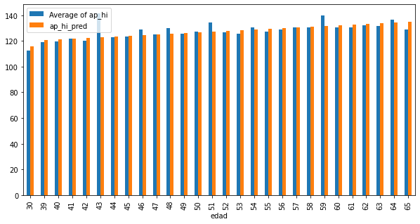

```python
df_age[['Average of ap_hi', 'ap_hi_pred']].plot(kind='bar', figsize=(10, 5))
```

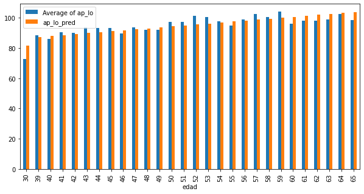

```python
df_age[['Average of ap_lo', 'ap_lo_pred']].plot(kind='bar', figsize=(10, 5))
```

1. ¿Cuál es la presión arterial hi y lo esperada para una persona de 76 años?

Genera una función que calcule lo anterior

```python
edad_calcular=76

def presionLo(edad):
    # Use the regressor_lo model to predict the ap_lo
    return regressor_lo.predict([[edad]])[0][0]

presionLo(edad_calcular)
```

```
110.65215141810583
```

```python
def presionHi(edad):
  # Use the regressor_hi model to predict the ap_hi
  return regressor_hi.predict([[edad]])[0][0]

presionHi(edad_calcular)
```

```
141.20998022461038
```

# Guardar el resultado como pdf

- Exporta el notebook a formato HTML.

```python
! jupyter nbconvert --to HTML '/content/drive/MyDrive/SemanaTec/arte-analitica/6.3 - Actividad Regresion Linea.ipynb'
```

- Haz doble clic en el archivo nuevo que se creó dentro de la carpeta `arte-analitica` y en la parte superior derecha dale clic en **imprimir**
- Imprime el archivo como *PDF* y súbelo a Canvas.